[figure not shown]

## Introduction

1. What is the average, median, and standard deviation for departure delay, arrival delay, and air time?
2. What the number of flights for each airline?
3. Are there seasonal trend (e.g. number of flights per month)?
4. How high are flight departure delays throughout the day?
5. What is the relationship between air time and distance?
6. Which routes observe the most flights, and how can this inform operational decisions?
7. Are certain days more prone to operational disruptions?
8. What insights can be derived from analyzing aircraft age in relation to flight frequency?
9. What factors influence customer satisfaction?

## 1. Descriptive Statistics

### Our Capabilities

At FLYDATA, we specialize in transforming raw aviation data into actionable insights that empower our customers to optimize their operations and enhance customer satisfaction. By providing critical statistics such as the average, median, and standard deviation for departure delay, arrival delay, and air time, we enable our clients to gain a comprehensive understanding of their flight punctuality and operational efficiency.

### Analysis

| variable | mean | median | sd |
| --- | --- | --- | --- |
| Departure Delay | 13.837372 | -2 | 54.31385 |
| Arrival Delay | 4.344803 | -10 | 57.86889 |
| Airtime | 141.820258 | 121 | 89.17256 |

### Findings

Departure and arrival delays both have negative medians, suggesting that flights were often early, yet the means are positive, indicating a significant number of very late flights. The large standard deviations across all variables reflect considerable variability in delays and airtime.

## 2. Number of Flights Analysis

### Capabilities

Knowing the total flight count for each airline provides our clients with crucial information to assess market share, identify competitive strengths, and spot potential opportunities for collaboration or strategic alliances. This data allows airlines to benchmark themselves against competitors, evaluate their fleet utilization, and optimize route planning.

### Analysis

| carrier | number_of_flights | name |
| --- | --- | --- |
| YX | 88785 | Republic Airline |
| UA | 79641 | United Air Lines Inc. |
| B6 | 66169 | JetBlue Airways |
| DL | 61562 | Delta Air Lines Inc. |
| 9E | 54141 | Endeavor Air Inc. |
| AA | 40525 | American Airlines Inc. |
| NK | 15189 | Spirit Air Lines |
| WN | 12385 | Southwest Airlines Co. |
| AS | 7843 | Alaska Airlines Inc. |
| OO | 6432 | SkyWest Airlines Inc. |
| F9 | 1286 | Frontier Airlines Inc. |
| G4 | 671 | Allegiant Air |
| HA | 366 | Hawaiian Airlines Inc. |
| MQ | 357 | Envoy Air |

### Findings

Republic Airline flew the highest number of flights, indicating its significant role in overall air traffic compared to other carriers, while Hawaiian Airlines Inc. and Envoy Air operated the fewest flights, suggesting a more limited operational scale or niche markets. The considerable disparity in flight count among carriers emphasizes the varied market presence and capacity of airlines, with larger carriers like Republic and United Air Lines Inc. covering more extensive networks.

## 3. Seasonal Trends

### Our Capabilities

We harness the power of data analytics to uncover seasonal trends that are pivotal for strategic planning and operational efficiency in the aviation industry. Analyzing the number of flights per month allows us to identify seasonal patterns that have significant implications for airlines and airports alike.

[interactive chart not shown]

### Findings

The data reveals that March had the highest number of flights at 39,514, possibly due to increased demand during spring break or seasonal travel. Meanwhile, February experienced the fewest flights with 34,761, which might be attributable to it being the shortest month and potentially facing less demand in winter travel.

## 4. Departure and Arrival Delays throughout the Day

### Our Capabilities

By providing insights into these patterns, we help airlines and airports optimize their schedules, enhance ground operations, and minimize delays. This data-driven approach not only enhances operational effectiveness but also significantly improves passenger experience by reducing wait times and maintaining reliable schedules.

[interactive chart not shown]

### Findings

The data indicates that both average departure and arrival delays tend to increase as the day progresses, with the highest delays occurring late at night; for instance, the average departure delay peaks at 32.04 minutes at 11 PM. This pattern likely arises due to the cumulative effect of delays accumulating throughout the day and a possible reduction in airport operations or staff capacity during nighttime hours.

## 5. The Relationship between Airtime and Distance?

### Our Capabilities

By offering a detailed analysis of the air time and distance relationship, we enable airlines to optimize route planning, improve flight scheduling, and enhance overall operational performance, ensuring a balance between efficiency, cost, and customer satisfaction.

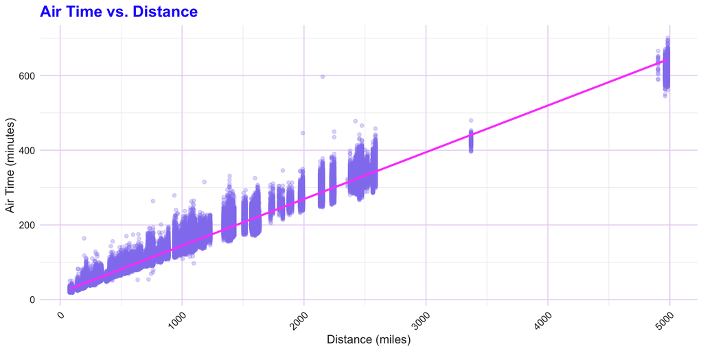

### Findings

A near-perfect correlation between distance and airtime suggests that, as expected, longer distances result in proportionally longer airtimes, indicating efficient and consistent flight operations without major disruptions. This correlation confirms that most flights maintain a consistent speed and route efficiency across varying distances, reinforcing that the flight time is, for the most part, directly dependent on the distance traveled.

## 6. Busiest Routes

### Question

FLYDATA begins by identifying the busiest routes. Insights into high-traffic corridors can drive strategic planning for airlines and airports.

[interactive chart not shown]

### Findings

The route from John F. Kennedy International Airport (JFK) in New York to Los Angeles International Airport (LAX) is the busiest, with 10,045 flights, underscoring the high demand for travel between New York City and Los Angeles, which are major hubs for both business and leisure. Similarly, the route from LaGuardia Airport (LGA) in New York to Chicago O’Hare International Airport (ORD) follows closely with 9,923 flights, highlighting the importance of the connection between New York City and Chicago.

On the other hand, flights like the one from Newark Liberty International Airport (EWR) to University Park Airport (SCE) in State College, Pennsylvania, and from LaGuardia (LGA) to Blue Grass Airport (LEX) in Lexington, Kentucky, each had only one flight, indicating these routes may serve niche markets or specific passenger needs rather than regular demand.

## 7. Delays by Day of the Week

### Question

FLYDATA investigates whether certain days endure more delays, thus suggesting staffing and scheduling efficiency opportunities.

### Analysis

Average Departure Delay by Day of the Week

| weekday | avg_dep_delay |
| --- | --- |
| Monday | 14.73471 |
| Tuesday | 10.85576 |
| Wednesday | 10.60587 |
| Thursday | 11.90029 |
| Friday | 16.58209 |
| Saturday | 15.84804 |
| Sunday | 16.99358 |

[figure not shown]

### Findings

The data suggests that Sundays and Fridays experience the highest average departure delays, with 16.99 and 16.58 minutes respectively, which may be influenced by increased travel activity and congestion typically associated with weekends and the close of the work week. Conversely, Tuesdays and Wednesdays show the lowest average delays, at 10.86 and 10.61 minutes respectively, possibly reflecting reduced travel demand and smoother airport operations mid-week.

## 8. Aircraft Age Analysis

### Question

Our analysis examines the relationship between aircraft age and usage, providing insights into fleet management strategies.

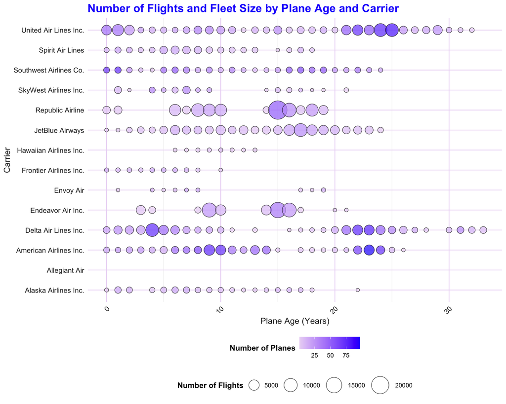

## 9. Influences on Customer Satisfaction

### Question

Customer satisfaction is a multidimensional aspect that’s pivotal for the sustained success and reputation of airlines and airports. At FLYDATA, we analyze various factors influencing customer satisfaction to provide our clients with insights for enhancing passenger experiences and ensuring customer loyalty. Here’s a look at some key insights into customer satisfaction:

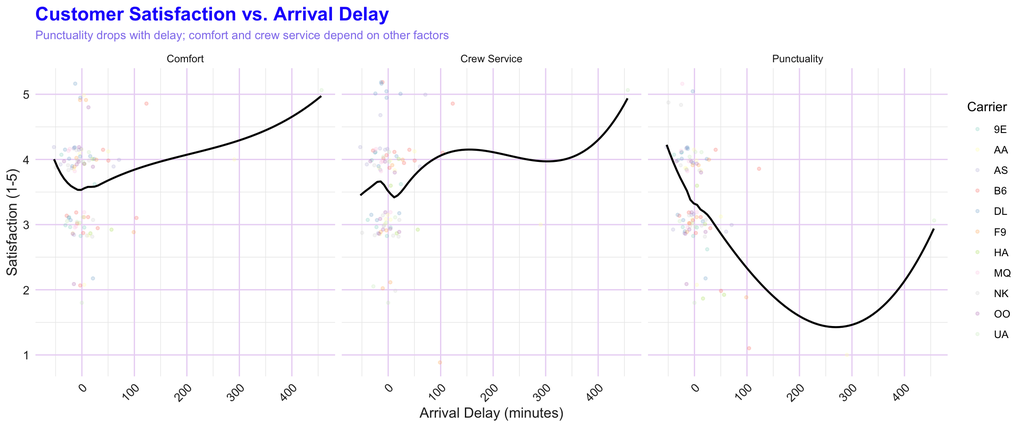

## Wind-Up!

This demonstration from FLYDATA illustrates how our data-driven insights can shape operational excellence in the aviation industry. From understanding route dynamics to optimizing aircraft usage, FLYDATA empowers stakeholders to make informed decisions. For bespoke analysis and deeper dives into your specific needs, connect with our team to explore customized solutions.